# ALY 6050 Module 2 Project: Simulation of Emergency Facilities Readiness

Shivangi Vashi, Yihong Qiu, Md Tajrianul Islam

3/1/2020

#### Course Instructor: Cartik Saravanamuthu

# I. Introduction

A simulation is an implementation of a model over a given period (Qayumi, 2010). When well developed and implemented, a simulation has the potential to bring a model to life and demonstrate how a particular subject or phenomenon will behave. This week’s assignment has introduced us to the concepts of simulation by predicting number of victims expected by hospital and how long it would take to transport the victims to the hospital for the given conditions. We have also performed exploratory data analysis and created charts to show Law of Large Numbers in action for Beth Israel Medical hospital. The data used for analysis is part of planning projects to determine how effectively local emergency facilities such as local hospitals can handle natural disasters (weather, fire,…).

# Analysis

# Part1

### 5000 Simulations of Disaster Victims

I first simulated 5000 random values using triangular probability distribution function with minimum 20 victims, maximum 300 and a peak of 80 victims, since the information says that the total number of victims is best approximated by a triangular probability distribution.

```r
a<-20
b<-300
c<-80

sim<-runif(5000)

 A<-a+sqrt((b-a)*(c-a)*sim)
 B<-b-sqrt((b-a)*(b-c)*(1-sim))
 C<-(c-a)/(b-a)
 Tdist<-ifelse(sim<C,A,B)
Hospital<-c("Beth Israel Medical", "Tufts Medical", "Massachusetts General", "Boston Medical", "Brigham and Women's")
TTinMins<-c(18,12,20,8,15)
TTinHrs<-TTinMins/60
HosAlloc<-c(0.15,0.2,0.2,0.3,0.15)
Hos_TT_Allocation<-data.frame(Hospital,HosAlloc,TTinMins,TTinHrs)
Hos_TT_Allocation
```

```
##                Hospital HosAlloc TTinMins   TTinHrs
## 1   Beth Israel Medical     0.15       18 0.3000000
## 2         Tufts Medical     0.20       12 0.2000000
## 3 Massachusetts General     0.20       20 0.3333333
## 4        Boston Medical     0.30        8 0.1333333
## 5   Brigham and Women's     0.15       15 0.2500000
```

```r
#Hospital_Allocation<-data.frame(Hospital,HosAlloc)
```

### Part 1 a. Average Number of Victims that can be expected in each hospital

Then, using the allocation percentages for each hospital, I calculated Average number of victims that can be expected at each hospital as seen below.

```r
#Allocated victims for each simulation for the hospitals
BIM<-HosAlloc[1]*Tdist
Tufts<-HosAlloc[2]*Tdist
MG<-HosAlloc[3]*Tdist
BM<-HosAlloc[4]*Tdist
Brigham<-HosAlloc[5]*Tdist

Hospital_Allocated_Table<-data.frame(BIM,Tufts,MG,BM,Brigham)


#Avg number of victims expected at each hospital
AvgNumVict<-data.frame("Hospital"=Hospital,"AvgNumofVictims"=c(mean(BIM),mean(Tufts),mean(MG),mean(BM),mean(Brigham)))
AvgNumVict
```

```
##                Hospital AvgNumofVictims
## 1   Beth Israel Medical        19.86113
## 2         Tufts Medical        26.48151
## 3 Massachusetts General        26.48151
## 4        Boston Medical        39.72226
## 5   Brigham and Women's        19.86113
```

### 1. b. Avg Total Time in Hours

For each hospital, I then calculated the average total time in hours needed to transport all the victims using the given transport time

```r
#Avg Total time in hours to transport all victims
AvgTimeinHrs<-AvgNumVict$AvgNumofVictims*Hos_TT_Allocation$TTinHrs
AvgTimeinHours<-data.frame("Hospital"=Hospital,"AvgTimeinHours"=AvgTimeinHrs)
AvgTimeinHours
```

```
##                Hospital AvgTimeinHours
## 1   Beth Israel Medical       5.958339
## 2         Tufts Medical       5.296301
## 3 Massachusetts General       8.827168
## 4        Boston Medical       5.296301
## 5   Brigham and Women's       4.965282
```

### 1.c Law of Large Numbers for Beth Israel Medical

The law of large numbers states that as the number of trials becomes larger, the observed average approaches the theoretial average. I created a scatter plot that shows that as the sample size increases, the sample observed mean will approach the theoretical mean I did this for a sample size of 1, 2, and so on upto a sample size of 500.

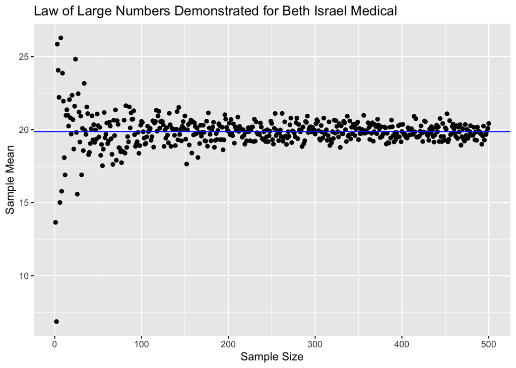

```r
library(ggplot2)

#meanIBM<-mean(BIM)
max_sample_size<-500
mean_vec<-rep(0,max_sample_size) # mean of samples
for(n in 1:max_sample_size){
  values<-sample(BIM,n)
  mean_vec[n]<-mean(values)
}

df<-data.frame("No_Samples"=seq(1,max_sample_size),"Mean_Vec"=mean_vec)
gplot<-ggplot(df,
       aes(seq(1,max_sample_size),mean_vec))+
       geom_point() +
       geom_hline(yintercept = mean(BIM),color="blue")

LawofLN<-gplot+labs(title="Law of Large Numbers Demonstrated for Beth Israel Medical", x="Sample Size", y="Sample Mean")
LawofLN
```

The blue line represents the theoretial mean for Beth Isreal Medical. As is observed, as the sample size increases, the sample means come close to this theoretical mean, hence proving the law of large numbers, showing the Law of Large Number in action for the Beth Israel Medical

### 1. d. i 95% Confidence interval for total transport time

To find the 95% confidence interval for the total transport time for the Beth Israel Medical hospital, we first had to create an object BIMTT and calculate the total transport time with the use of the 5000 simulations and then used the library Rmisc to calculate to confidence interval with a single line of code. The code used to find 95% confidence interval is given below:

```r
library(Rmisc)
BIMTT <- BIM*TTinHrs[1]
CI(BIMTT, ci=0.95)
```

```
##    upper     mean    lower
## 6.033140 5.958339 5.883537
```

### 1. d. ii Determining probability distribution that best fits the total transport time in hours

```r
library(MASS)
# checking best fit distribution using logarithmic likelihood: whichever has the highest loglik value is the best fitting probability distribution
fitdistr(BIMTT, "t", lower = 0.01)$loglik
```

```
## [1] -12056.73
```

```r
fitdistr(BIMTT, "normal", lower = 0.01)$loglik
```

```
## [1] -12056.73
```

```r
fitdistr(BIMTT, "logistic", lower = 0.01)$loglik
```

```
## [1] -12179.15
```

```r
fitdistr(BIMTT, "weibull", lower = 0.01)$loglik
```

```
## [1] -11836.66
```

```r
fitdistr(BIMTT, "gamma", lower = 0.01)$loglik
```

```
## [1] -11811.3
```

```r
fitdistr(BIMTT, "lognormal", lower = 0.01)$loglik
```

```
## [1] -11912.49
```

```r
fitdistr(BIMTT, "exponential", lower = 0.01)$loglik
```

```
## [1] -13923.96
```

### d. iii Chi- Square Test for Goodness of Fit

To check if our assumption was right, we find the probability distribution values by pgamma() fuction and perform Chi-squared Goodness of fit test using chisq.test() function. The codes are given below:

```r
fitdistr(BIMTT, "gamma")
```

```
##      shape         rate
##   4.62139085   0.77561749
##  (0.08929113) (0.01583070)
```

```r
s1 <- 4.63559370
r1 <- 0.77543095

#Since gamma has largest, we find probability distribution values
gammadistvalue <- pgamma(BIMTT,s1,r1)

#Perform chi-square test of goodness of fit on the same
ctest<-chisq.test(gammadistvalue)
#function to print whether null is rejected or not rejected
test_classify <- function(test_object, alpha)
{
  # reject NULL if p-value < alpha ,0.05, ie doesnt fit the distribution

  if (test_object["p.value"] < alpha)
  {
    print(sprintf("NULL hypothesis should be rejected for `%s` test. p-value=%f is smaller than alpha=%#.4f",
            test_object["method"], test_object["p.value"],alpha))
    boolean_reject = TRUE
  } else {
    print(sprintf("NULL hypothesis cannot be rejected for `%s` test. p-value=%f is greater or equal than alpha=%#.4f",
            test_object["method"], test_object["p.value"],alpha))
    boolean_reject = FALSE
  }
  return (boolean_reject)
}

boolean_result = test_classify(ctest, 0.05)
```

```
## [1] "NULL hypothesis cannot be rejected for `Chi-squared test for given probabilities` test. p-value=1.000000 is greater or equal than alpha=0.0500"
```

```r
cat("Reject NULL hypothesis:", boolean_result)
```

```
## Reject NULL hypothesis: FALSE
```

### e. Exploratory Analysis of t

```r
#Constructing t

library(MASS)
AvgTTforAllVictims<-colMeans(Hospital_Allocated_Table)*TTinMins
AvgTTforAllVictims
```

```
##      BIM    Tufts       MG       BM  Brigham
## 357.5003 317.7781 529.6301 317.7781 297.9169
```

```r
# Checking distributions using logarithmic likelihood
fitdistr(AvgTTforAllVictims, "t", lower = 0.01)$loglik
```

```
## [1] -18.61864
```

```r
fitdistr(AvgTTforAllVictims, "normal", lower = 0.01)$loglik
```

```
## [1] -29.30729
```

```r
fitdistr(AvgTTforAllVictims, "logistic", lower = 0.01)$loglik
```

```
## [1] -29.17407
```

```r
fitdistr(AvgTTforAllVictims, "weibull", lower = 0.01)$loglik
```

```
## [1] -29.5839
```

```r
fitdistr(AvgTTforAllVictims, "gamma", lower = 0.01)$loglik
```

```
## [1] -28.82144
```

```r
fitdistr(AvgTTforAllVictims, "lognormal", lower = 0.01)$loglik
```

```
## [1] -28.60316
```

```r
fitdistr(AvgTTforAllVictims, "exponential", lower = 0.01)$loglik
```

```
## [1] -34.48743
```

```r
fitdistr(AvgTTforAllVictims,"exponential")
```

```
##       rate
##   0.002746342
##  (0.001228202)
```

```r
rate<-0.002700442
##Confidence Interval of T
CI(AvgTTforAllVictims,0.95)
```

```
##    upper     mean    lower
## 482.1040 364.1207 246.1374
```

```r
#Exponential dsitribution values of t
expondistvalues<-pexp(AvgTTforAllVictims, rate)


c_tttest<-chisq.test(expondistvalues)
#function to print whether null is rejected or not rejected
test_classify <- function(test_object, alpha)
{
  # reject NULL if p-value < alpha ,0.05, ie doesnt fit the distribution

  if (test_object["p.value"] < alpha)
  {
    print(sprintf("NULL hypothesis should be rejected for `%s` test. p-value=%f is smaller than alpha=%#.4f",
            test_object["method"], test_object["p.value"],alpha))
    boolean_reject = TRUE
  } else {
    print(sprintf("NULL hypothesis cannot be rejected for `%s` test. p-value=%f is greater or equal than alpha=%#.4f",
            test_object["method"], test_object["p.value"],alpha))
    boolean_reject = FALSE
  }
  return (boolean_reject)
}

boolean_result = test_classify(c_tttest, 0.05)
```

```
## [1] "NULL hypothesis cannot be rejected for `Chi-squared test for given probabilities` test. p-value=0.999744 is greater or equal than alpha=0.0500"
```

```r
cat("Reject NULL hypothesis:", boolean_result)
```

```
## Reject NULL hypothesis: FALSE
```

# Part 2

### 2. a. 5000 Simulations of Normally distributed disaster victims

In part2, the total number of victims are assumed to be normally distributed. I first simulated 5000 random values using normal distribution function using mean of 150 victims and standard deviation of 50 vicitms.

I then created all the tables given in the instructions that will be used in the calculations.

```r
Ndist<-rnorm(n=5000,150,50)
TTinMins2<-c(18,12,20,8,15)
SDinMins<-c(4,5,3,2,5)
TTinHrs2<-TTinMins2/60
HosAlloc<-c(0.15,0.2,0.2,0.3,0.15)
```

### 2.a Average Number of Victims in each hospital

I then found the Average number of victims in each hospital and average time to transport all victims in a similar fashion as Part 1:

```r
#Allocated victims for each simulation for the hospitals
BIM2<-rnorm(Ndist,18,4)
Tufts2<-rnorm(Ndist,12,5)
MG2<-rnorm(Ndist,20,3)
BM2<-rnorm(Ndist,8,2)
Brigham2<-rnorm(Ndist,15,5)

Hospital_Allocated_Table2<-data.frame(BIM2,Tufts2,MG2,BM2,Brigham2)

#Avg number of victims expected at each hospital
AvgNumVict2<-data.frame("Hospital"=Hospital,"AvgNumofVictims2"=c(mean(BIM2),mean(Tufts2),mean(MG2),mean(BM2),mean(Brigham2)))
AvgNumVict2
```

```
##                Hospital AvgNumofVictims2
## 1   Beth Israel Medical        17.958289
## 2         Tufts Medical        11.899561
## 3 Massachusetts General        20.036850
## 4        Boston Medical         7.991546
## 5   Brigham and Women's        14.940646
```

### 2. b. Avg Time in Hours

```r
#Avg Total time in hours to transport all victims
AvgTimeinHrs2<-AvgNumVict2$AvgNumofVictims2*TTinHrs2
AvgTimeinHours2<-data.frame("Hospital"=Hospital,"AvgTimeinHours2"=AvgTimeinHrs2)
AvgTimeinHours
```

```
##                Hospital AvgTimeinHours
## 1   Beth Israel Medical       5.958339
## 2         Tufts Medical       5.296301
## 3 Massachusetts General       8.827168
## 4        Boston Medical       5.296301
## 5   Brigham and Women's       4.965282
```

### 2 c. Law of Large Numbers for Beth Israel Medical

Law of large numbers is shown for the average number of victims expected in Beth Israel Medical for a normally distributed frequency of disaster victims.

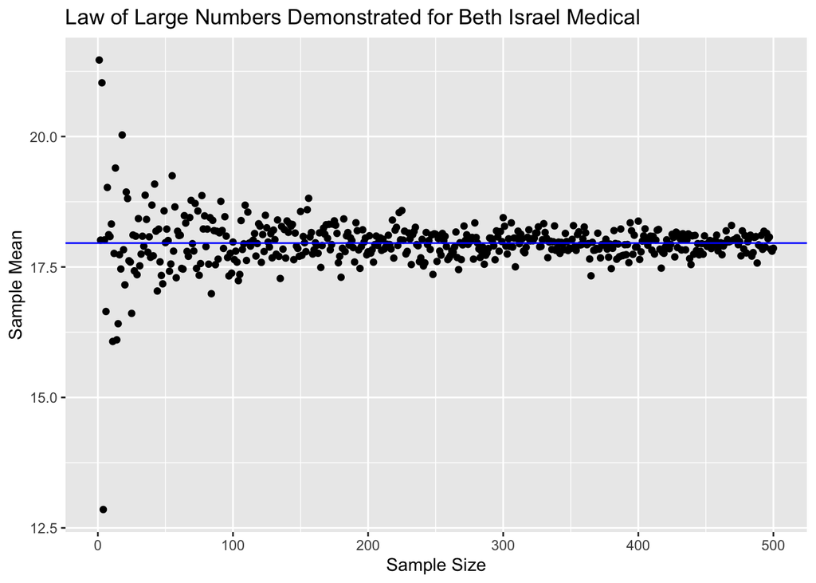

```r
library(ggplot2)


max_sample_size2<-500
mean_vec2<-rep(0,max_sample_size2) # mean of samples
for(n in 1:max_sample_size2){
  values2<-sample(BIM2,n)
  mean_vec2[n]<-mean(values2)
}


df<-data.frame("No_Samples"=seq(1,max_sample_size2),"Mean_Vec"=mean_vec2)
gplot<-ggplot(df,
       aes(seq(1,max_sample_size2),mean_vec2))+
       geom_point() +
       geom_hline(yintercept = mean(BIM2),color="blue")

LawofLN2<-gplot+labs(title="Law of Large Numbers Demonstrated for Beth Israel Medical", x="Sample Size", y="Sample Mean")
LawofLN2
```

### d. i 95% Confidence interval for total transport time

```r
library(Rmisc)



BIM2TT <- BIM2*TTinHrs2[1]
CI(BIM2TT, ci=0.95)
```

```
##    upper     mean    lower
## 5.420538 5.387487 5.354436
```

### d. ii Determining probability distribution that best fits the total transport time in hours

We followed the same procedure as part 1 to find the best fit for probability distribution and the highest loglik value was for Normal Distribution.

So after finding the shape and rate of the normal distribution we ran the Chi-squared Goodness of fit test and found out the p value is ~1.000000 which is greater or equal than alpha=0.0500. So NULL hypothesis cannot be rejected.

```r
library(MASS)
# checking best fit distribution using logarithmic likelihood: whichever has the highest loglik value is the best fitting probability distribution
fitdistr(BIM2TT, 't', lower = 0.01)$loglik
```

```
## [1] -7972.824
```

```r
fitdistr(BIM2TT, 'normal', lower = 0.01)$loglik
```

```
## [1] -7972.821
```

```r
fitdistr(BIM2TT, 'logistic', lower = 0.01)$loglik
```

```
## [1] -8029.969
```

```r
#cannot be gamma,exp etc because values arent >=0

fitdistr(BIM2TT,"normal")
```

```
##       mean          sd
##   5.38748657   1.19199178
##  (0.01685731) (0.01191992)
```

```r
mean<-5.40055321
sd<- 1.17743550
#Since normal has largest, we find probability distribution values
normaldistvalue <- pnorm(BIM2TT,mean,sd)

#Perform chi-square test of goodness of fit on the same
c_normtest<-chisq.test(normaldistvalue)
#function to print whether null is rejected or not rejected
test_classify <- function(test_object, alpha)
{
  # reject NULL if p-value < alpha ,0.05, ie doesnt fit the distribution

  if (test_object["p.value"] < alpha)
  {
    print(sprintf("NULL hypothesis should be rejected for `%s` test. p-value=%f is smaller than alpha=%#.4f",
            test_object["method"], test_object["p.value"],alpha))
    boolean_reject = TRUE
  } else {
    print(sprintf("NULL hypothesis cannot be rejected for `%s` test. p-value=%f is greater or equal than alpha=%#.4f",
            test_object["method"], test_object["p.value"],alpha))
    boolean_reject = FALSE
  }
  return (boolean_reject)
}

boolean_result = test_classify(c_normtest, 0.05)
```

```
## [1] "NULL hypothesis cannot be rejected for `Chi-squared test for given probabilities` test. p-value=1.000000 is greater or equal than alpha=0.0500"
```

```r
cat("Reject NULL hypothesis:", boolean_result)
```

```
## Reject NULL hypothesis: FALSE
```

### 2. e Exploratory analysis of average transport time in minutes per victim for entire process of transporting all victims (t)

```r
#Constructing t

library(MASS)
AvgTTforAllVictims2<-colMeans(Hospital_Allocated_Table2)*TTinMins2
AvgTTforAllVictims2
```

```
##      BIM2    Tufts2       MG2       BM2  Brigham2
## 323.24919 142.79473 400.73700  63.93237 224.10968
```

```r
# Checking distributions using logarithmic likelihood
fitdistr(AvgTTforAllVictims2, 't', lower = 0.01)$loglik
```

```
## [1] -31.06885
```

```r
fitdistr(AvgTTforAllVictims2, 'normal', lower = 0.01)$loglik
```

```
## [1] -31.06868
```

```r
fitdistr(AvgTTforAllVictims2, 'logistic', lower = 0.01)$loglik
```

```
## [1] -31.32541
```

```r
fitdistr(AvgTTforAllVictims2, 'gamma', lower = 0.01)$loglik
```

```
## [1] -31.01298
```

```r
fitdistr(AvgTTforAllVictims2, 'lognormal', lower = 0.01)$loglik
```

```
## [1] -31.26871
```

```r
fitdistr(AvgTTforAllVictims2, 'exponential', lower = 0.01)$loglik
```

```
## [1] -32.21132
```

```r
#gamma has largest hence gamma fits best
fitdistr(AvgTTforAllVictims2,"gamma")
```

```
##       shape         rate
##   2.908590896   0.012593235
##  (1.725494433) (0.008127968)
```

```r
s2<-2.924021920
r2<-0.012650868
##Confidence Interval of T
CI(AvgTTforAllVictims2,0.95)
```

```
##     upper      mean     lower
## 398.77285 230.96460  63.15634
```

```r
#Exponential dsitribution values of t
gammadistvalues2<-pgamma(AvgTTforAllVictims2,s2, r2)


c_gtest<-chisq.test(gammadistvalues2)
#function to print whether null is rejected or not rejected
test_classify <- function(test_object, alpha)
{
  # reject NULL if p-value < alpha ,0.05, ie doesnt fit the distribution

  if (test_object["p.value"] < alpha)
  {
    print(sprintf("NULL hypothesis should be rejected for `%s` test. p-value=%f is smaller than alpha=%#.4f",
            test_object["method"], test_object["p.value"],alpha))
    boolean_reject = TRUE
  } else {
    print(sprintf("NULL hypothesis cannot be rejected for `%s` test. p-value=%f is greater or equal than alpha=%#.4f",
            test_object["method"], test_object["p.value"],alpha))
    boolean_reject = FALSE
  }
  return (boolean_reject)
}

boolean_result = test_classify(c_gtest, 0.05)
```

```
## [1] "NULL hypothesis cannot be rejected for `Chi-squared test for given probabilities` test. p-value=0.920107 is greater or equal than alpha=0.0500"
```

```r
cat("Reject NULL hypothesis:", boolean_result)
```

```
## Reject NULL hypothesis: FALSE
```

## Part4:

### Qualitative and Quantitative differences between simulation outputs of Parts 1 and 2

Simulation 1 performs a triangular probability distribution with minimum, maximum and peak value. Simulation 2 performs a normally distribution with mean and standard deviation. The difference between simulation 1 and 2 is the range of output. Simulation 1 has finite range of data output, while simulation 2 has infinite range. In addition, triangular distributed simulation variables are not symmetric, however, normally distributed simulation variables are symmetric.

## Part5:

### How the information can be used for planning purposes:

In the first part we assume the data is triangularly distributed, and we simulate according to that scenario. When we know little about what to expect during a disaster, we could use the results of Part1 and to see how many victims each hospital could take, and also how long it would take to transport all victims to the five hospitals, and accoringly add more transport vehicles and plan road diversions to minimize time taken. If we have more information on the scenario and know that total number of victims are normally distributed, we can again find out how many victims each hospital can accomodate and also total transport time for each. Since we also modeled t, ie average time it takes to transport the victims, we have a better idea on how long it will take to transport given number of victims for any scenario. In this way University administrators can be better prepared in the event of a disaster.

## Part6:

### How each simulation can be changed to provide additional useful information

It would be helpful if the victims can be categorized according to severity of injusries, if such data can be provided and simulated, and then the allocation can be performed considering this parameter. The simulation will help better allocate resources and optimize the workflow. A detailed study on this is given in (Sukho Jin, 2014).

# I. Conclusion

The simulation procedure involves conducting experiments which closely resemble an actual situation in order to provide answers to real life problems. Practical problems from the very simple to the most complex can be solved (or at least approximated) by using simple simulation. Our analysis of the given data can help authorities to plan ahead for emergency situations. Being able to estimate the expected number of victims, can help hospitals to pre plan have the required number of doctors and nurses ready if such situation occurs. Also, if we can guess the average victim transportation time, we can prioritize depending on the severity of the victims or choose closest hospital as we also know the average time taken to reach particular hospitals. In this assignment, we learned different R functions to do descriptive, heuristic and prescriptive analysis.

### Works Cited

Qayumi, A. K. (2010). Centre of Excellence for Simulation Education and Innovation (CESEI). Journal of Surgical Education, 266-269.

Dr. Nic. (2013). Creative Maths. Let’s hear it for the Triangular Distribution. Retrieved from https://creativemaths.net/blog/triangular-dist/

Sukho Jin, S. J. (2014). logistics model for the transport of disaster victims with various injuries and survival probabilities. Annals of Operations Research , 17-33. Retrieved from https://link.springer.com/article/10.1007/s10479-013-1515-0